# Onlineforløb i lineær programmering

Sune L. Gadegaard

14/11/2019

## Guide til forløbet

Kære alle

I denne uge er undervisningen, som tidligere nævnt, lidt anderledes end den ellers plejer at være. Baseret på tidligere studerendes feedback, kan netop denne del af pensum være svær, da man både skal lære at bruge Excels solver, lære teorien om lineær programmer samt at modellere lineære programmer. Derfor har jeg lavet dette lille online forløb, som består af tekst som skal studeres, videoer som skal ses og opgaver som skal løses. Det er væsentligt, at I forholder jer til rækkefølgen af elementerne, da der er en bevist progression i forløbene. I har mulighed for at pause og gense videoerne. På den måde kan I gense de passager som I finder svære, så benyt jer af det!

Start med Del 1 og gå først videre med Del 2 når I har styr på elementerne i Del 1.

#### Diskussion

I kan løbenden benytte jer af det “Diskussion board” der er oprettet på https://blackboard.au.dk/ hvor I kan stille spørgsmål, besvare spørgsmål som I kender svaret på, samt diskutere jeres forståelse af stoffet.

På den måde kan I hjælpe hinanden og få en dybere forståelse af materialet: En basis-forståelse er relativt nem at opnå, men at forstå matrialet dybt nok til at forklare det til andre, kræver lidt ekstra. Jeg vil være aktiv på bloggen som moderator og jeg skal nok besvare spørgsmål som ikke umiddelbart bliver besvaret af jeres kolleger.

God fornøjelse!

# Del 1

Det er som før nævnt væsentligt at i udfører opgaverne nedenfor i den rækkefølge de kommer i her på siden. Ellers vil nogle opgaver potentielt ikke give mening eller simpelthen være for svære.

**God arbejdslyst**

### Opgave 1

For at få en grundlæggende forståelse af lineær programmering skal I læse afsnit 2.2, 2.3, 2.4, 2.5, 2.6, 2.7 og 2.8 i [BRS].

### Opgave 2

I det følgende vil vi gennemgå den grafiske løsningsmetode til løsning af lineære programmer og vi vil tage udgangspunkt i mincasen “Tele”. Derefter kommer vi formulere en LP-model som løser problemet opstillet i minicase dokumentets “Tech”-case.

#### Formulering af LP-modellen for virksomeheden Tele

Virksomheden Tele producerer og markedsfører to slags TV-apparater, betegnet med Astro og Cosmo. På forhånd foretagne beregninger godtgør, at dækningsbidraget pr. enhed er hhv. 20 kr. og 10 kr.

Den daglige produktionskapacitet er 70 for Astro og 50 for Cosmo. For at producere et TV-apparat af typen Astro kræves én time i afdeling 1 og én time i afdeling 2. For at producere et TV-apparat af typen Cosmo kræves to timer i afdeling 1 og én time i afdeling 2. På dagsbasis er der 120 timer til rådighed i afdeling 1, mens der er 90 timer til rådighed i afdeling 2.

Virksomhedens planlægningsproblem består i at tilrettelægge den daglige produktion således, at det samlede dækningsbidrag bliver størst muligt under hensyn til de begrænsede ressourcer i de to afdelinger.

##### 4-trins raketten

For at løse et lineært program grafisk, skal det maksimalt indeholde af 2-variabler, da det er noget bøvlet at tegne i højere dimensioner. For indtegne *det brugbare område* i et koordinatsystem, bestemmer vi os her for at afbilde $X_A$ på den vandrette akse og $X_C$ på den lodrette akse. For at tegne det brugbare område, skal vi indtegne et område, hvor alle punkterne opfylder alle begrænsningerne. Det vil i vores tilfælde være alle de punkter $(X_A,X_C)$ som opfylde ligger *under* funktionerne: \begin{align} X_A + 2X_C&= 120 \end{align} \begin{align} X_A+X_C&= 90\\ \end{align} \begin{align} X_A&= 70\\ \end{align} \begin{align} X_C&= 50\\ \end{align} og over funktionerne $X_A=0$ og $X_C=0$.Da $X_C$ variablen har indtaget “$y$” variables plads her (den er afbildet på den lodrette akse) vil vi isolore $X_C$ i den første funktion, hvorved vi får \[ X_C = -\frac{1}{2}X_A+60 \] hvilket vil sige, at vi kan indtegne en funktion i et koordinatsystem som har hældning $-\frac{1}{2}$ og skæring med $X_C$-aksen i $(0,60)$ (indtegnet som sort linje nedenfor). Gøres dette tilsvarende for alle funktionerne ovenfor opnår vi det brugbare område givet ved det gule område i nedenstående figur.

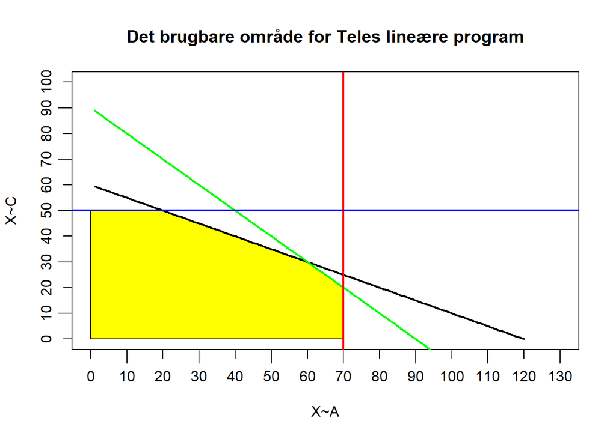

Det vil altså sige, at alle brugbare løsninger til problemet, ligger i det gule område, og dermed ligger en optimal løsning også i dette område.

Vi kan nu prøve at indtegne objektfunktionen i det ovenstående $(X_A,X_C)$-koordinatsystem. For at kunne gøre dette, kan vi prøve at se hvilke løsninger som kan give et samlet dækningsbidrag på 1000 kroner. Det er altså alle kombinationer af $X_A$ og $X_C$ som opfylder \[ 20X_A + 10X_C = 1000 \Leftrightarrow X_C = -2X_A +100 \] I nedenstående diagram er *objektfunktionslinjen* afbildet med en stiblet linje.

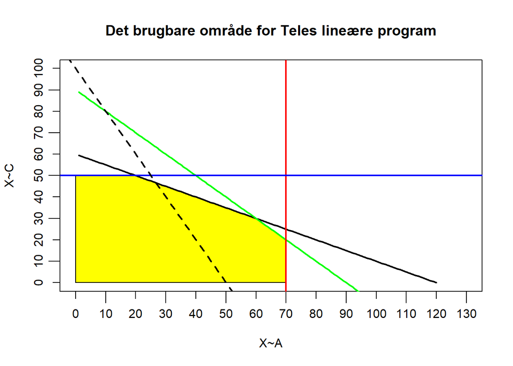

Fra dette diagram kan vi altså se, at alle punkter på den stiblede linje giver et samlet dækningsbidrag på 1000,- og at alle punkter i det gule område er brugbare produktionsplaner. Det vil sige, at alle punkter på den stiplede linje, som ligger i det gule område er gennemførbare produktionsplaner, som giver et dækningsbidrag på 1000 kroner. Hvorledes man så finder det optimale totale dækningsbidrag kan du se i videon i Opgave 3.

### Opgave 3

Her skal du se en video, hvor det lineære program for virksomheden Tele *løses*. Det vil sige, at vi finder en optimal løsning til det lineære program fra Opgave 2 (Læg her mærke til, at vi bevidst sige *en* optimal løsning og ikke *den* optimale løsning. Dette skyldes, at der sagtens kan være mere end en løsning som leder til et maksimalt dækningsbidrag. Det skal vi undersøge nærmere senere i kurset).

[video not shown]

### Opgave 4

Det er selvfølgelig ikke praktisk muligt at løse generelle lineære programmer vha. den grafiske metode; tænk bare på at tegne sig ud at et lineært program med 10 variabler! Derfor skal vi være i stand til at løse lineære programmer vha. en *Solver*. En solver er et stykke software som er i stand til at løse (solve) optimeringsproblemer og der er mange forskellige solvere på markedet som kan løse lineære programmer. Der findes faktisk solvere der kan køre på de mest gængse mobilplatforme fx. [Linear Optimization LITE](https://play.google.com/store/apps/details?id=com.vishalaksh.optimization&hl=en_US) til Android og [iSolveModel](https://apps.apple.com/us/app/isolvemodel/id387627473) til iPhone.

I dette krusus bruger vi den solver som følger med Excel. Den hedder blot Solver (på engelsk) eller Problemløser (på dansk) og kan håndtere både lineære og *ikke-linære* problemer hvor nogle af variablerne skal være heltallige. Før vi kan gå i gang med at bruge Solver skal den aktiveres/installeres i Excel. Dette kan du gøre ved at følge denne guide:

1. Tjek først om Solver/Problemløser er aktiveret
   - Åben Excel og naviger til Data-tabben
   - Her skal I kigge i “Analyse” kategorien om Solver/Problemløser figurerer
   - Hvis Solver/Problemløser er synlig er alt som det skal være og I kan stoppe her. Ellers fortsæt til punkt 2.
2. Gå til Filer-> Indstillinger. Her skal I klikke på “Tilføjelsesprogrammer” og marker derefter “Excel-tilføjelsesprogrammer” i feltet “Administrer”.
3. Klik på “Søg”
4. Marker afkrydsningsfeltet “Tilføjelsesprogrammet Problemløser” i feltet “Tilgængelige tilføjelsesprogrammer” og klik herefter “Ok”

Har du brug for mere hjælp kan du kigge [her for en dansk guide](https://support.office.com/da-dk/article/indl%C3%A6se-tilf%C3%B8jelsesprogrammet-probleml%C3%B8ser-i-excel-612926fc-d53b-46b4-872c-e24772f078ca#OfficeVersion=Windows) eller [her for en engelsk guide](https://support.office.com/en-us/article/load-the-solver-add-in-in-excel-612926fc-d53b-46b4-872c-e24772f078ca).

I den nedenstående video gennemgås hvorledes Solver bruges:

[figure not shown]

[Soapbox - Solution of linear program using Excel](https://soapbox.wistia.com/videos/gfiWCGlCw1)

### Opgave 5

Vi har nu set hvorledes vi kan formulere et linæert program med to variabler, hvordan vi kan løse det med den grafiske metode og hvorledes vi kan løse det vha. Excels Solver. Vi skal nu et skridt videre hvor vi skal formulere et lineært program med tre variabler. Vi skal arbejde med følgende mini-case

#### Virksomheden Tech

Virksomheden Tech producerer og markedsfører tre produkter, betegnet med hhv. model A, model B og model C. På forhånd foretagne beregning godtgør, at dækningsbidraget per enhed er hhv. 8 kr., 15 kr. og 25 kr.

På ugentlig basis er der behov for at producere minimum 100 af model A, 150 af model B samt 75 af model C. Hvert af produkterne kræver en vis behandlingstid i Tech’s tre afdelinger: produktionsafdelingen, samleafdelingen og i pakkeri/forsendelsesafdelingen.

Tabellen viser tidsforbruget i timer pr. *dusin* af de tre produkter i hver af de tre afdelinger.

| Afdeling | Model A | Model B | Model C |
| --- | --- | --- | --- |
| Produktionsafdeling | 3 | 3.5 | 5 |
| Samleafdeling | 4 | 5 | 8 |
| Forsendelsesafdeling | 1 | 1.5 | 3 |

I den kommende uge er der 150 timer til rådighed i produktionsafdelingen, 200 timer i samleafdelingen og 60 timer i forsendelsesafdelingen. Virksomhedens planlægningsproblem består i at tilrettelægge produktionen, så det samlede dækningsbidrag bliver størst muligt under hensyn til de begrænsede ressourcer i de tre afdelinger.

#### Din opgave

Du skal nu forsøge at opstille et lineært program som kan maksimere Virksomehden Tech’s totale dækningsbidrag ved produktion af modellerne A, B og C.

### Opagve 6

I denne opgave skal du læse (og forstå) en besvarelse af forrige opgave. Det vil altså sige, at hvis du er 100% sikker på, at du lavede forrige opgave rigtigt kan du springe denne opgave over. Hvis du derimod har brug for at tjekke om du gjorde det rigtigt, eller måske har brug for at se det gennemgået, så følg med her.

Vi kan løse Opgave 5, altså opstilling af et lineært program som maksimerer virksomheden Tech’s totale dækningsbidrag, vha. af 4-trins raketten som følger:

2. Vi skal nu definere vores beslutningsvariabler. I denne case er en naturlig definition givet ved \begin{align} X_A&:\ Antal\ af\ Model\ A,\ der\ produceres\ per \ uge\\ X_B&:\ Antal\ af\ Model\ B,\ der\ produceres\ per \ uge\\ X_C&:\ Antal\ af\ Model\ C,\ der\ produceres\ per \ uge \end{align}
3. Efter definitionen af variablerne kan vi opskrive objektfunktionen som skal *maksimere det totale dækningsbidrag* for virksomheden Tech. Dækningsbidraget per Model A er 8 kroner, hvorfor det totale dækningsbidrag vi kan opnå fra Model A er givet ved 8 kroner $\times$ antal Model A der produceres: $8X_A$. Ligeledes får vi at dækningsbidraget som opnås ved produktion af Model B og C er henholdsvist $15X_B$ og $25X_C$. Summen af de enkelte dækningsbidrag giver det totale dækningsbidrag og objektfunktionen bliver således \[ \max 8X_A+15X_B+25X_C \]
4. Vi er nu kommet frem til at formulere modellens begrænsninger. Der kommer til at være en begrænsning for hver model, som sørger for at minimumskravet til produktionene er overholdt. Derudover kommer der en begrænsning for hver af de tre afdelinger. Det vil altså sige seks begrænsninger i alt hvortil vi skal lægge de tre ikke-negativitetsbegrænsninger på variablerne.

De første tre begrænsninger giver *nedre grænser* for variablerne (modsta Tele-casen hvor der var øvre grænser for variablerne): \begin{align} X_A&\geq 100\\ X_B&\geq 150\\ X_C&\geq 75 \end{align} Disse begrænsninger sørger blot for, at vi mindst producerer den ønskede mængde af de tre produkter.

Lad os nu betragte Produktionsafdelingen. Der har vi fra punkt 1 i 4-trinsraketten, at Model A bruger $\tfrac{3}{12}$ timer per stk., Model B bruger $\tfrac{3.5}{12}$ timer per stk. mens Model C bruger $\tfrac{5}{12}$ timer per stk.. Det leder altså til en begrænsning for Produktionsafdelingen givet ved \[ \frac{3}{12}X_A + \frac{3.5}{12}X_B + \frac{5}{12}X_C\leq 150 \] På Samme vis, kan vi opskrive begrænsningerne for Samleafdelingen og Forsendelsesafdelingen: \begin{align} \frac{4}{12}X_A + \frac{5}{12}X_B + \frac{8}{12}X_C&\leq 200\\ \frac{1}{12}X_A + \frac{1.5}{12}X_B + \frac{3}{12}X_C&\leq 60 \end{align} Nu mangler vi blot at huske at alle variabler skal være ikke-negative \[ X_A,X_B,X_C\geq 0 \] og så kan vi opsummere det samlede lineære program til :

| $\max$ | $8X_A$ | + | $15X_B$ | + | $25X_C$ |  |  |
| --- | --- | --- | --- | --- | --- | --- | --- |
|  | $X_A$ |  |  |  |  | $\geq$ | 100 |
|  |  |  | $X_B$ |  |  | $\geq$ | 150 |
|  |  |  |  |  | $X_C$ | $\geq$ | 75 |
|  | $\tfrac{3}{12}X_A$ | + | $\tfrac{3.5}{12}X_B$ | + | $\tfrac{5}{12}X_C$ | $\leq$ | 150 |
|  | $\tfrac{4}{12}X_A$ | + | $\tfrac{5}{12}X_B$ | + | $\tfrac{8}{12}X_C$ | $\leq$ | 200 |
|  | $\tfrac{1}{12}X_A$ | + | $\tfrac{1.5}{12}X_B$ | + | $\tfrac{3}{12}X_C$ | $\leq$ | 60 |
| $X_A,X_B,X_C$ |  |  |  |  |  | $\geq$ | 0 |

Vi kan her lægge mærke til, at vi har en masse brøker i begrænsningerne hvilket kan være lidt bøvlet at regne rundt på, når det skal skrives ind i en solver. Derfor man også simpelthen gange igennem med 12 i alle de begræsninger hvor der ellers er delt med 12. Gør man det får man at det lineære program kan skrives som

| $\max$ | $8X_A$ | + | $15X_B$ | + | $25X_C$ |  |  |
| --- | --- | --- | --- | --- | --- | --- | --- |
|  | $X_A$ |  |  |  |  | $\geq$ | 100 |
|  |  |  | $X_B$ |  |  | $\geq$ | 150 |
|  |  |  |  |  | $X_C$ | $\geq$ | 75 |
|  | $3X_A$ | + | $3.5X_B$ | + | $5X_C$ | $\leq$ | 1800 |
|  | $4X_A$ | + | $5X_B$ | + | $8X_C$ | $\leq$ | 2400 |
|  | $1X_A$ | + | $1.5X_B$ | + | $3X_C$ | $\leq$ | 720 |
| $X_A,X_B,X_C$ |  |  |  |  |  | $\geq$ | 0 |

I videoen nedenfor kan du se mig gennemgå formuleringen af Tech-casen som er beskrevet ovenfor. I anden halvdel af videoen formuleres Tech casen således at variablerne ikke måler antal producerede enheder men derimod antal producerede dusin:

[video not shown]

### Opgave 7

Du har nu forsøgt at løse Tech’s problem selv (Opgave 5) og har set hvordan det (også) kan gøres, da du læste teksten til Opgave 6.

I denne opgave skal du se hvorledes vi kan *løse* problemet vha. af Excels SOlver/Probelmløser. Alt du skal gøre her er at se video hvorefter du selv skal løse problemet i Excel.

[video not shown]